# Multiple Correspondence Analysis

Dataset datensatz_synthesise_users_gda

This dataset contains 100 individuals and 48 variables.

### 1. Study of the outliers

The analysis of the graphs does not detect any outlier.

### 2. Inertia distribution

The inertia of the first dimensions shows if there are strong relationships between variables and suggests the number of dimensions that should be studied.

The first two dimensions of MCA express **40.76%** of the total dataset inertia ; that means that 40.76% of the individuals (or variables) cloud total variability is explained by the plane. This is an intermediate percentage and the first plane represents a part of the data variability. This value is strongly greater than the reference value that equals **12.95%**, the variability explained by this plane is thus highly significant (the reference value is the 0.95-quantile of the inertia percentages distribution obtained by simulating 960 data tables of equivalent size on the basis of a uniform distribution).

From these observations, it may be interesting to consider the next dimensions which also express a high percentage of the total inertia.

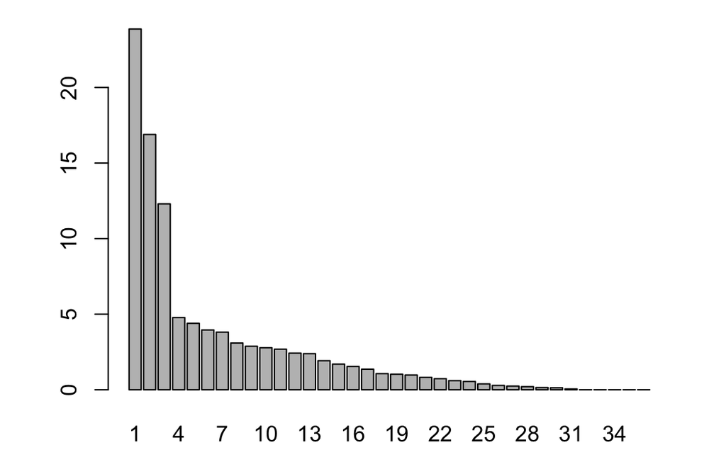

**Figure 2 - Decomposition of the total inertia on the components of the MCA**

An estimation of the right number of axis to interpret suggests to restrict the analysis to the description of the first 3 axis. These axis present an amount of inertia greater than those obtained by the 0.95-quantile of random distributions (53.06% against 18.63%). This observation suggests that only these axis are carrying a real information. As a consequence, the description will stand to these axis.

### 3. Description of the plane 1:2

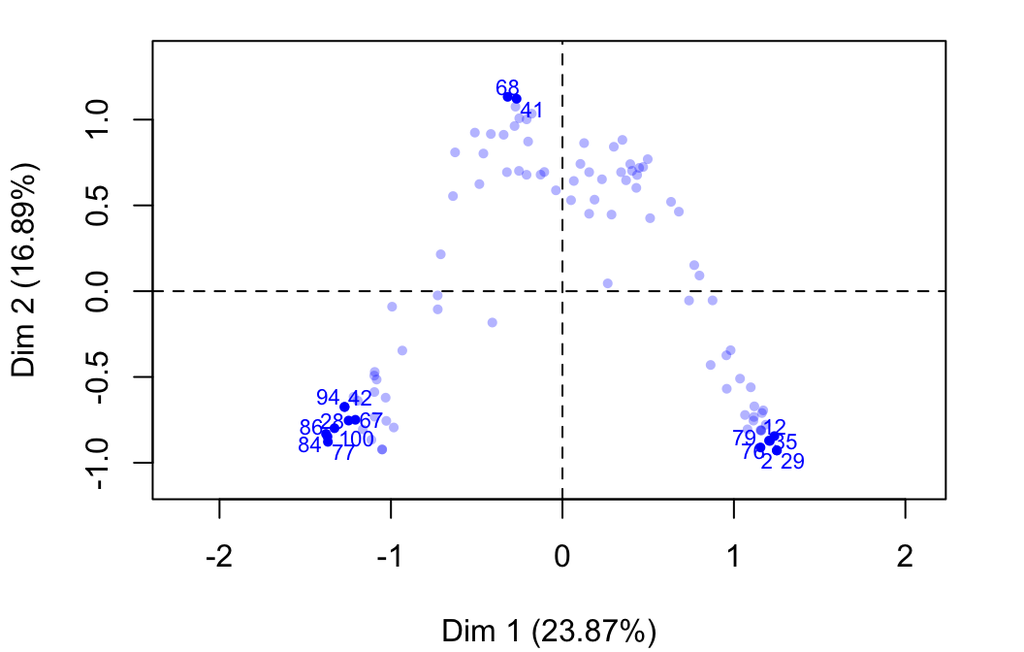

**Figure 3.1 - Individuals factor map (MCA)** *The labeled individuals are those with the higher contribution to the plane construction.*

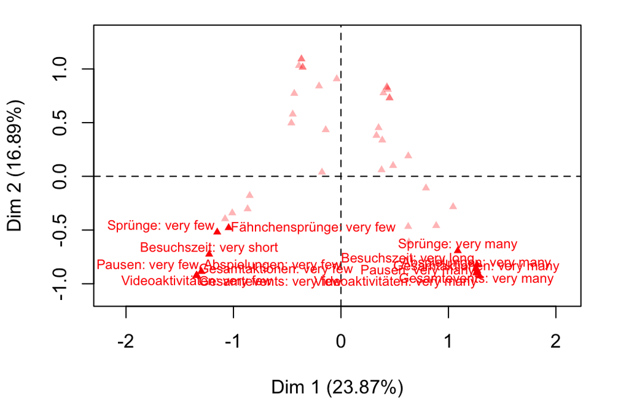

**Figure 3.2 - Variables factor map (MCA)** *The labeled variables are those the best shown on the plane.*

The **dimension 1** opposes individuals such as *29*, *2*, *12*, *35*, *76* and *79* (to the right of the graph, characterized by a strongly positive coordinate on the axis) to individuals such as *84*, *86*, *77*, *100*, *28*, *67*, *42* and *94* (to the left of the graph, characterized by a strongly negative coordinate on the axis).

The group in which the individuals *29*, *2*, *12*, *35*, *76* and *79* stand (characterized by a positive coordinate on the axis) is sharing :

- high frequency for factors like *visit_video_event_actions_pause=Pausen: very many*, *visit_event_action_videos=Videoaktivitäten: very many*, *total_events=Gesamtevents: very many*, *total_actions=Gesamtaktionen: very many*, *total_visit_duration=Besuchszeit: very long*, *visit_video_event_actions_play=Abspielungen: very many*, *visit_video_event_actions_jump=Sprünge: very many*, *total_visits=Gesamtbesuche: very many*, *visit_video_event_actions_cuepoint=Fähnchensprünge: very many* and *visit_video_event_actions_speed=Geschwindigkeitsveränderungen: very many* (factors are sorted from the most common).
- low frequency for factors like *visit_video_event_actions_jump=Sprünge: few*, *visit_video_event_actions_cuepoint=NA*, *total_visit_duration=Besuchszeit: short*, *visit_video_event_actions_cuepoint=Fähnchensprünge: few*, *total_visits=Gesamtbesuche: few*, *total_visits=Gesamtbesuche: very few*, *visit_video_event_actions_cuepoint=Fähnchensprünge: very few*, *average_visit_duration=Durchschnittliche Besuchszeit: very short*, *visit_video_event_actions_speed=Geschwindigkeitsveränderungen: very few* and *average_visit_events=Durchschnittliche Events: very few* (factors are sorted from the rarest).

The group in which the individuals *84*, *86*, *77*, *100*, *28*, *67*, *42* and *94* stand (characterized by a negative coordinate on the axis) is sharing :

- high frequency for factors like *visit_event_action_videos=Videoaktivitäten: very few*, *total_events=Gesamtevents: very few*, *total_actions=Gesamtaktionen: very few*, *visit_video_event_actions_play=Abspielungen: very few*, *visit_video_event_actions_pause=Pausen: very few*, *total_visit_duration=Besuchszeit: very short*, *visit_video_event_actions_jump=Sprünge: very few*, *average_visit_events=Durchschnittliche Events: very few*, *visit_video_event_actions_speed=Geschwindigkeitsveränderungen: very few* and *average_visit_duration=Durchschnittliche Besuchszeit: very short* (factors are sorted from the most common).
- low frequency for factors like *average_visit_events=Durchschnittliche Events: very many*, *average_visit_duration=Durchschnittliche Besuchszeit: very long*, *visit_video_event_actions_cuepoint=Fähnchensprünge: many*, *total_visits=Gesamtbesuche: very many*, *visit_video_event_actions_cuepoint=Fähnchensprünge: very many*, *visit_video_event_actions_speed=Geschwindigkeitsveränderungen: very many*, *visit_video_event_actions_jump=Sprünge: very many*, *visit_video_event_actions_play=Abspielungen: very many*, *visit_video_event_actions_pause=Pausen: very many* and *visit_event_action_videos=Videoaktivitäten: very many* (factors are sorted from the rarest).

The **dimension 2** opposes individuals such as *68* and *41* (to the top of the graph, characterized by a strongly positive coordinate on the axis) to individuals such as *29*, *2*, *12*, *35*, *76* and *79* (to the bottom of the graph, characterized by a strongly negative coordinate on the axis).

The group in which the individuals *68* and *41* stand (characterized by a positive coordinate on the axis) is sharing :

- high frequency for the factors *visit_video_event_actions_play=Abspielungen: few*, *visit_video_event_actions_pause=Pausen: few*, *visit_event_action_videos=Videoaktivitäten: few*, *total_events=Gesamtevents: few*, *total_actions=Gesamtaktionen: few*, *visit_video_event_actions_jump=Sprünge: few*, *average_visit_events=Durchschnittliche Events: few*, *total_visit_duration=Besuchszeit: short*, *visit_video_event_actions_cuepoint=Fähnchensprünge: few* and *total_visits=Gesamtbesuche: few* (factors are sorted from the most common).

The group in which the individuals *29*, *2*, *12*, *35*, *76* and *79* stand (characterized by a negative coordinate on the axis) is sharing :

- high frequency for factors like *visit_video_event_actions_pause=Pausen: very many*, *visit_event_action_videos=Videoaktivitäten: very many*, *total_events=Gesamtevents: very many*, *total_actions=Gesamtaktionen: very many*, *total_visit_duration=Besuchszeit: very long*, *visit_video_event_actions_play=Abspielungen: very many*, *visit_video_event_actions_jump=Sprünge: very many*, *total_visits=Gesamtbesuche: very many*, *visit_video_event_actions_cuepoint=Fähnchensprünge: very many* and *visit_video_event_actions_speed=Geschwindigkeitsveränderungen: very many* (factors are sorted from the most common).
- low frequency for factors like *visit_video_event_actions_jump=Sprünge: few*, *visit_video_event_actions_cuepoint=NA*, *total_visit_duration=Besuchszeit: short*, *visit_video_event_actions_cuepoint=Fähnchensprünge: few*, *total_visits=Gesamtbesuche: few*, *total_visits=Gesamtbesuche: very few*, *visit_video_event_actions_cuepoint=Fähnchensprünge: very few*, *average_visit_duration=Durchschnittliche Besuchszeit: very short*, *visit_video_event_actions_speed=Geschwindigkeitsveränderungen: very few* and *average_visit_events=Durchschnittliche Events: very few* (factors are sorted from the rarest).

### 4. Description of the dimension 3

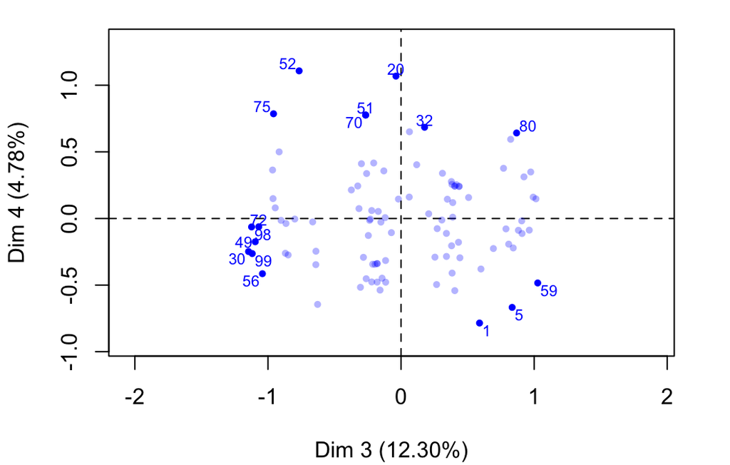

**Figure 4.1 - Individuals factor map (MCA)** *The labeled individuals are those with the higher contribution to the plane construction.*

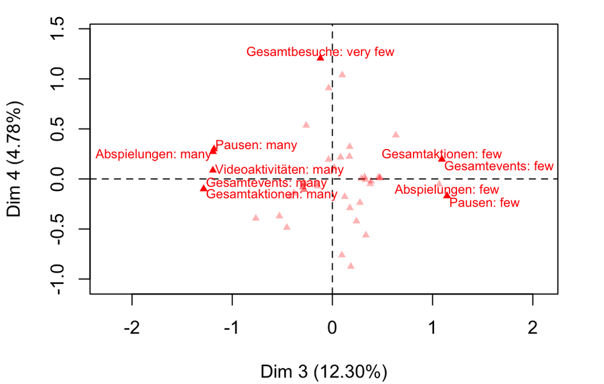

**Figure 4.2 - Variables factor map (MCA)** *The labeled variables are those the best shown on the plane.*

The **dimension 3** opposes individuals such as *59*, *80*, *5* and *1* (to the right of the graph, characterized by a strongly positive coordinate on the axis) to individuals such as *30*, *99*, *98*, *56*, *49* and *72* (to the left of the graph, characterized by a strongly negative coordinate on the axis).

The group in which the individuals *59*, *80*, *5* and *1* stand (characterized by a positive coordinate on the axis) is sharing :

- high frequency for the factors *visit_video_event_actions_play=Abspielungen: few*, *visit_video_event_actions_pause=Pausen: few*, *total_events=Gesamtevents: few*, *total_actions=Gesamtaktionen: few*, *visit_event_action_videos=Videoaktivitäten: few*, *total_visit_duration=Besuchszeit: short*, *average_visit_duration=Durchschnittliche Besuchszeit: very short*, *average_visit_events=Durchschnittliche Events: few* and *total_visits=Gesamtbesuche: few* (factors are sorted from the most common).
- low frequency for factors like *average_visit_events=Durchschnittliche Events: many*, *total_visits=Gesamtbesuche: many*, *visit_video_event_actions_jump=Sprünge: many*, *average_visit_events=Durchschnittliche Events: very many*, *total_visit_duration=Besuchszeit: long*, *visit_video_event_actions_cuepoint=Fähnchensprünge: very many*, *visit_video_event_actions_play=Abspielungen: many*, *visit_video_event_actions_pause=Pausen: many*, *visit_event_action_videos=Videoaktivitäten: many* and *total_events=Gesamtevents: many* (factors are sorted from the rarest).

The group in which the individuals *30*, *99*, *98*, *56*, *49* and *72* stand (characterized by a negative coordinate on the axis) is sharing :

- high frequency for factors like *total_events=Gesamtevents: many*, *total_actions=Gesamtaktionen: many*, *visit_video_event_actions_play=Abspielungen: many*, *visit_video_event_actions_pause=Pausen: many*, *visit_event_action_videos=Videoaktivitäten: many*, *visit_video_event_actions_cuepoint=Fähnchensprünge: very many*, *total_visit_duration=Besuchszeit: long*, *visit_video_event_actions_jump=Sprünge: many*, *average_visit_events=Durchschnittliche Events: many* and *total_visits=Gesamtbesuche: many* (factors are sorted from the most common).
- low frequency for the factors *visit_video_event_actions_cuepoint=Fähnchensprünge: very few*, *visit_video_event_actions_jump=Sprünge: very few*, *total_visits=Gesamtbesuche: very few*, *total_visit_duration=Besuchszeit: short*, *visit_event_action_videos=Videoaktivitäten: few*, *visit_video_event_actions_play=Abspielungen: few*, *visit_video_event_actions_pause=Pausen: few*, *total_events=Gesamtevents: few* and *total_actions=Gesamtaktionen: few* (factors are sorted from the rarest).

### 5. Classification

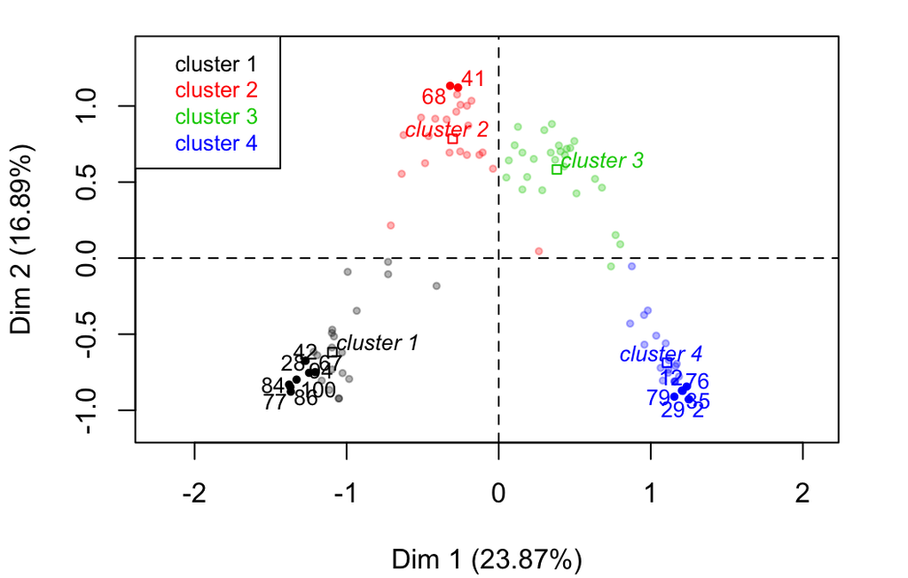

**Figure 5 - Ascending Hierachical Classification of the individuals.** *The classification made on individuals reveals 4 clusters.*

The cluster 3 is made of individuals sharing :

- high frequency for the factors *visit_event_action_videos=Videoaktivitäten: many*, *total_events=Gesamtevents: many*, *total_actions=Gesamtaktionen: many*, *visit_video_event_actions_play=Abspielungen: many*, *visit_video_event_actions_pause=Pausen: many*, *total_visit_duration=Besuchszeit: long*, *visit_video_event_actions_jump=Sprünge: many*, *average_visit_duration=Durchschnittliche Besuchszeit: long*, *average_visit_events=Durchschnittliche Events: many* and *total_visits=Gesamtbesuche: many* (factors are sorted from the most common).
- low frequency for factors like *visit_video_event_actions_play=Abspielungen: few*, *visit_video_event_actions_pause=Pausen: few*, *total_events=Gesamtevents: few*, *total_actions=Gesamtaktionen: few*, *visit_video_event_actions_cuepoint=Fähnchensprünge: very few*, *visit_event_action_videos=Videoaktivitäten: few*, *visit_event_action_videos=Videoaktivitäten: very many*, *average_visit_events=Durchschnittliche Events: very few*, *total_events=Gesamtevents: very many* and *total_actions=Gesamtaktionen: very many* (factors are sorted from the rarest).